# Ensemble Methods

```python
import addutils.toc ; addutils.toc.js(ipy_notebook=True)
```

```python
import warnings
import scipy.io
import numpy as np
import pandas as pd
from sklearn import tree
from time import time
from sklearn import datasets, grid_search, cross_validation, metrics, ensemble
from IPython.core.display import Image
from addutils import css_notebook
css_notebook()
```

## 1 Ensemble Methods

Ensemble Methods combine the predictions of several models in order to improve generalizability / robustness over a single model.

Two families of ensemble methods are usually distinguished:

- **B**ootstrap **agg**regat**ing** **(Bagging) Methods**, also called **Averaging Methods**: train multiple models together by randomly *sample with replacement (values can be duplicated)* from the dataset and then average (or vote) the predictions. Bagging works better with High-Variance models by decreasing variance without changing the Bias. Implementations:
  - **`RandomForestClassifier` / `RandomForestRegressor`**
  - **`ExtraTreesClassifier` / `ExtraTreesRegressor`**
- **Boosting Methods**: incrementally build an ensemble by training each new model instance to emphasize the training instances that previous models mis-classified. In some cases, boosting has been shown to yield better accuracy than bagging, but it also tends to be more likely to over-fit the training data.
  - **`AdaBoostClassifier` / `AdaBoostRegressor`**
  - **`GradientBoostingClassifier` / `GradientBoostingRegressor`**

## 2 Random Forests

Eeach tree in the ensemble is built from a **sample drawn with replacement (i.e., a bootstrap sample)**. In addition, when splitting a node, the split is the best **split among a random subset of the features**. As a result, the bias increases but the variance usually decreases faster.

The main parameters to adjust when using these methods is `n_estimators` and `max_features`.

`n_estimators` is the number of trees in the forest. The larger the better, but also the longer it will take to compute. In addition, note that results will stop getting significantly better beyond a critical number of trees.

`max_features`: The number of features to consider when looking for the best split. The lower the greater the reduction of variance, but also the greater the increase in bias. Use `int` ==> number of features, `float` ==> %, `auto` ==> sqrt(n_feat), `none` ==> all.

`max_depth` if `none` the nodes are expanded until pure or `min_samples_split`.

`min_samples_split` / `min_samples_leaf` minimum samples in a node to split / in resulting leaf.

If n_jobs=k then computations are partitioned into k jobs, and run on k cores of the machine. If n_jobs=-1 then all cores available on the machine are used.

```python
warnings.filterwarnings("ignore", category=DeprecationWarning)
pd.options.display.notebook_repr_html = True

iris = datasets.load_iris()
# We skip the scaling because the tree-based models are less sensitive to scaling
df = pd.DataFrame(iris.data, columns=iris.feature_names)
# Split Training and Validation Sets:
idx_train, idx_valid = cross_validation.train_test_split(df.index, test_size=0.15)
df_train, df_valid = df.ix[idx_train], df.ix[idx_valid]
y_train, y_valid = iris.target[idx_train], iris.target[idx_valid]
```

```python
rfc = ensemble.RandomForestClassifier(compute_importances=False)
# Here we define the random state to have always the same results
# Sometimes n_jobs=-1 crashes the kernel, here we use conservatively n_jobs=1
params = {'n_estimators':[5, 10, 20, 40],
          'max_features':[2, 3, 4],
          'max_depth':[4, 6, 8],
          'min_samples_split':[2, 4],
          'min_samples_leaf':[1, 2, 4],
          'bootstrap':[True],
          'random_state':[0]}
t0 = time()
grid = grid_search.GridSearchCV(rfc, params, cv=3, n_jobs=1)
grid.fit(df_train, y_train)
rfc_best = grid.best_estimator_

print metrics.confusion_matrix(rfc_best.predict(df_valid), y_valid)
print '\nBest Params: N est:%3i - Mx feat:%2i - Mx dpth:%2i - Mn s.splt:%2i - Mn s.leaf:%2i - Bootstrap:%2i - F1:%.3f' %(rfc_best.n_estimators,
       rfc_best.max_features, rfc_best.max_depth, rfc_best.min_samples_split, rfc_best.min_samples_leaf, rfc_best.bootstrap,
       metrics.f1_score(rfc_best.predict(df_valid), y_valid))
print 'Done in %0.3f[s]' %(time() - t0)
```

```
[[7 0 0]
 [0 9 0]
 [0 0 7]]

Best Params: N est:  5 - Mx feat: 2 - Mx dpth: 4 - Mn s.splt: 2 - Mn s.leaf: 2 - Bootstrap: 1 - F1:1.000
Done in 9.202[s]
```

Let's have a look to one of the Random Forest Trees ([Graphviz](http://www.graphviz.org/) must be installed on your machine):

*The gini impurity: Used by the CART (classification and regression tree) algorithm, Gini impurity is a measure of how often a randomly chosen element from the set would be incorrectly labeled if it were randomly labeled according to the distribution of labels in the subset. Gini impurity can be computed by summing the probability of each item being chosen times the probability of a mistake in categorizing that item. It reaches its minimum (zero) when all cases in the node fall into a single target category.*

*Gini impurity reaches its maximum value when all classes in the table have equal probability.*

[figure not shown]

```python
idx = 1
with open("temp/temp.dot", 'w') as f:
    f = tree.export_graphviz(rfc_best.estimators_[idx], out_file=f)
! dot -Tpng temp/temp.dot -o temp/temp.png
Image("temp/temp.png")
```

```python
# TODO - Modify this code to automatically look for a specific leaf:
x = df_train.columns
L0 = df_train.copy()
L0['y_train'] = y_train
i = rfc_best.estimators_[idx].indices_
L0 = L0.loc[i,:]
L11 = L0[L0[x[2]]>2.35]
L21 = L11[L11[x[1]]>3.15]
L30 = L21[L21[x[2]]<=4.95]
print L0.shape, L11.shape, L21.shape, L30.shape
```

```
(81, 5) (56, 5) (10, 5) (3, 5)
```

```python
L30
```

|  | sepal length (cm) | sepal width (cm) | petal length (cm) | petal width (cm) | y_train |
| --- | --- | --- | --- | --- | --- |
| 50 | 7.0 | 3.2 | 4.7 | 1.4 | 1 |
| 51 | 6.4 | 3.2 | 4.5 | 1.5 | 1 |
| 56 | 6.3 | 3.3 | 4.7 | 1.6 | 1 |

**TODO -** Domanda per Gloria: riesci a capire che cos'è il "value" descritto nei rami puri dell'albero sopra?

## 3 Out of Bag Estimates

When using **ensemble methods base upon Bagging**, i.e. using sampling with replacement, part of the training set remains unused. For each classifier in the ensemble, a different part of the training set is left out. This left out portion can be used to **estimate the generalization error without having to rely on a separate Validation Set**. This estimate comes “for free” as no additional data is needed and can be used for model selection.

**Notice that** `oob_score` can be only calculated if `bootstrap=True`.

This is currently implemented in the following classes:

- `RandomForestClassifier` / `RandomForestRegressor`
- `ExtraTreesClassifier` / `ExtraTreesRegressor`
- `GradientBoostingClassifier` / `GradientBoostingRegressor` (only when `subsample` < 1.0)

Let's make an example with `RandomForestClassifier`:

**TODO -** Check if it's correct to use the OOB Scores for GridSearch

```python
print " I - OOB Score  F1 Score"
for n_estimators_ in xrange(5,11,5):
    for i in xrange(4):
        rfc = ensemble.RandomForestClassifier(n_estimators = 20,
                                              criterion = 'gini',
                                              max_features = 4,
                                              max_depth = 10,
                                              min_samples_split = 2,
                                              min_samples_leaf = 1,
                                              bootstrap = True,
                                              oob_score = True,
                                              n_jobs = 1,
                                              random_state = None,
                                              verbose = 0)
        rfc.fit(df_train,y_train)
        # print rfc.fit(df_train,y_train)
        # print metrics.confusion_matrix(rfc.predict(df_valid), y_valid)
        print "%2d - %9.3f %9.3f" % (i, rfc.oob_score_,
                                     metrics.f1_score(rfc.predict(df_valid), y_valid))
```

```
 I - OOB Score  F1 Score
 0 -     0.937     0.913
 1 -     0.953     1.000
 2 -     0.937     0.957
 3 -     0.937     0.957
 0 -     0.945     0.913
 1 -     0.953     0.957
 2 -     0.937     0.916
 3 -     0.945     0.957
```

## 4 Extremely Randomized Trees

In extremely randomized trees, randomness goes one step further in the way splits are computed.

As in random forests, a random subset of candidate features is used, *but instead of looking for the most discriminative thresholds, thresholds are drawn at random for each candidate feature and the best of these randomly-generated thresholds is picked as the splitting rule*.

This usually allows to **reduce the Variance** of the model a bit more, at the expense of a **slightly greater increase in Bias**:

```python
xtc = ensemble.ExtraTreesClassifier(compute_importances=False)
params = {'n_estimators':[5, 10, 15],
          'max_features':[3, 4],
          'max_depth':[4, 8, 12],
          'min_samples_split':[2, 4],
          'min_samples_leaf':[2, 4],
          'bootstrap':[True, False]}
t0 = time()
grid = grid_search.GridSearchCV(xtc, params, cv=7)
grid.fit(df_train, y_train)
xtc_best = grid.best_estimator_

print metrics.confusion_matrix(xtc_best.predict(df_valid), y_valid)
print '\nBest Params: N est:%3i - Mx feat:%2i - Mx dpth:%2i - Mn s.splt:%2i - Mn s.leaf:%2i - Bootstrap:%2i - F1:%.3f' %(xtc_best.n_estimators,
       xtc_best.max_features, xtc_best.max_depth, xtc_best.min_samples_split, xtc_best.min_samples_leaf, xtc_best.bootstrap,
       metrics.f1_score(xtc_best.predict(df_valid), y_valid))
print 'Done in %0.3f[s]' %(time() - t0)
```

```
[[7 0 0]
 [0 9 0]
 [0 0 7]]

Best Params: N est: 10 - Mx feat: 3 - Mx dpth: 8 - Mn s.splt: 4 - Mn s.leaf: 4 - Bootstrap: 1 - F1:1.000
Done in 7.425[s]
```

## 5 AdaBoost

**AdaBoost**, short for **Adaptive Boosting**, is a meta-algorithm, and can be used in conjunction with many other learning algorithms. The core principle of AdaBoost is to fit a sequence of weak learners (i.e., models that are only slightly better than random guessing, such as small decision trees) on repeatedly modified versions of the data. The predictions from all of them are then combined through a weighted majority vote (or sum) to produce the final prediction. AdaBoost is sensitive to noisy data and outliers. The classifiers it uses can be weak (i.e., display a substantial error rate), but as long as their performance is slightly better than random, they will improve the final model.

```python
adb = ensemble.AdaBoostClassifier()
params = {'n_estimators':[10, 20, 30, 40],
          'learning_rate':[0.1, 0.2, 0.5, 0.7, 1.0]}
t0 = time()
grid = grid_search.GridSearchCV(adb, params, cv=3)
grid.fit(df_train, y_train)
adb_best = grid.best_estimator_

print 'F1 Score'.ljust(20), ': %.3f[s]' %(time() - t0)
for key, value in grid.best_params_.items():
    print key.ljust(20), ':', value
print 'F1 Score'.ljust(20), ': %.3f' %(metrics.f1_score(adb_best.predict(df_valid), y_valid))
print '\nConfusion Matrix:'
print metrics.confusion_matrix(adb_best.predict(df_valid), y_valid)
```

```
F1 Score             : 1.306[s]
n_estimators         : 20
learning_rate        : 1.0
F1 Score             : 0.916

Confusion Matrix:
[[7 0 0]
 [0 9 2]
 [0 0 5]]
```

## 6 Gradient Tree Boosting

**Gradient Tree Boosting** or **Gradient Boosted Regression Trees (GBRT)** is a generalization of boosting methods by allowing optimization of an arbitrary differentiable loss function. It's made for regression and ca be adapted to classification.

The method was invented by *Jerome H. Friedman in 1999*.

- **ADVANTAGES**:
  - Natural handling of data of mixed type (= heterogeneous features)
  - Predictive power
  - Robustness to outliers in input space (via robust loss functions)
  - Support for different Loss functions
  - Automaticalli detects non-linear feature interactions
- **DISADVANTAGES**:
  - Requires careful tuning
  - Slow to train (but fast in prediction)
  - Cannot Extrapolate

The main parameters to adjust can be grouped in three classes: *Tree Structure, Regularization and Stocastic Gradient Boosting*:

- **Tree Structure**:
  - `max_depth`: it controls the maximum allowed level of interaction between variables. With `max_depth=2` no interaction between variables is allowed. With `max_depth=3` the model will include the effects of the interaction between two variable at most and so on. Typical values are [4, 6, 8].
  - `min_sample_leaf`: reduces the effects of outliers. Generally decreases Variance faster than increasing Bias.
- **Regularization**:
  - `n_estimators`: The number of boosting stages to perform (default=100). Since GBRT is fairly robust to overfitting is is usually advisable to set it much higher than default (eg. 3000-4000) when learning time is not an issue.
  - `learning_rate`: this controls the Shrinkage. It's a scale factor applied to tree predictions. Default is 0.1. A decrease in `learning_rate` (increase in Shrinkage) has the effect of "reinforce concept": the redundancy between trees increases. The effect is that the model with high Shrinkage usually requires more trees but show a much better Variance.
- **Stocastic Gradient Boosting**:
  - `subsample`: Choosing subsample < 1.0 leads to a reduction of variance and an increase in bias. It's the fraction of samples to be used for fitting the individual base learners.
  - `max_features`: The number of features to consider when looking for the best split. The lower the greater the reduction of variance, but also the greater the increase in bias. Use `int` ==> number of features, `float` ==> %, `auto` ==> sqrt(n_feat), `none` ==> all.

**Huperparameter Tuning - step 01**: do a grid search by using the maximum number of `n_estimators` compatible with your available computing time: the time required for the Grid Search scales almost linearly with the number of estimators, so a good approach is to do a first run with the default 100 estimators and predict the time required from the elapsed time.

```python
gtb = ensemble.GradientBoostingClassifier()
params = {'n_estimators':[100],
          'max_depth':[4, 6],
          'min_samples_leaf':[3, 5, 9],
          'learning_rate':[0.1, 0.05, 0.02],
          'subsample':[0.5, 1.0],
          'max_features':[2,3,4]}
t0 = time()
grid = grid_search.GridSearchCV(gtb, params, n_jobs=1)
grid.fit(df_train, y_train)
gtb_best = grid.best_estimator_
print 'Done in %0.3f[s]' %(time() - t0)
```

```
Done in 48.412[s]
```

```python
for key, value in grid.best_params_.items():
    print key.ljust(20), ':', value
print 'F1 Score'.ljust(20), ': %.3f' %(metrics.f1_score(gtb_best.predict(df_valid), y_valid))
print '\nConfusion Matrix:'
print metrics.confusion_matrix(gtb_best.predict(df_valid), y_valid)
```

```
learning_rate        : 0.1
min_samples_leaf     : 9
n_estimators         : 100
subsample            : 0.5
max_features         : 2
max_depth            : 4
F1 Score             : 0.913

Confusion Matrix:
[[7 0 0]
 [0 8 1]
 [0 1 6]]
```

**Huperparameter Tuning - step 02**: increase `n_estimators` and fine tune `learning_rate`:

```python
gtb = ensemble.GradientBoostingClassifier()
params = {'n_estimators':[400],
          'max_depth':[6],
          'min_samples_leaf':[9],
          'learning_rate':[0.05, 0.02, 0.01, 0.005],
          'subsample':[0.5],
          'max_features':[2]}
t0 = time()
grid = grid_search.GridSearchCV(gtb, params, cv=7, n_jobs=1)
grid.fit(df_train, y_train)
gtb_best = grid.best_estimator_
print 'Done in %0.3f[s]' %(time() - t0)
```

```
Done in 15.220[s]
```

```python
for key, value in grid.best_params_.items():
    print key.ljust(20), ':', value
print 'F1 Score'.ljust(20), ': %.3f' %(metrics.f1_score(gtb_best.predict(df_valid), y_valid))
print '\nConfusion Matrix:'
print metrics.confusion_matrix(gtb_best.predict(df_valid), y_valid)
```

```
learning_rate        : 0.05
min_samples_leaf     : 9
n_estimators         : 400
subsample            : 0.5
max_features         : 2
max_depth            : 6
F1 Score             : 0.913

Confusion Matrix:
[[7 0 0]
 [0 8 1]
 [0 1 6]]
```

```python
ensemble.GradientBoostingClassifier?
```

## 7 Feature importance evaluation

**TODO -** Check documentation **1.9.1.5.**: remake the same example using the "digits" instead of the "faces" dataset

```python
%matplotlib inline
import matplotlib.pyplot as plt
```

```python
import bokeh.plotting as bk
bk.output_notebook()
```

```
WARNING:bokeh.resources:Getting CDN URL for local dev version will not produce usable URL
```

BokehJS successfully loaded.

```python
from sklearn.datasets import fetch_olivetti_faces
from sklearn.ensemble import ExtraTreesClassifier
```

```python
# Number of cores to use to perform parallel fitting of the forest model
n_jobs = 1

# Load the faces dataset
data = fetch_olivetti_faces()
X = data.images.reshape((len(data.images), -1))
y = data.target

mask = y < 5  # Limit to 5 classes
X = X[mask]
y = y[mask]

# Build a forest and compute the pixel importances
t0 = time()
forest = ExtraTreesClassifier(n_estimators=1000, max_features=128)

forest.fit(X, y)
print("done in %0.3fs" % (time() - t0))
importances = forest.feature_importances_
importances = importances.reshape(data.images[0].shape)
```

```
done in 0.942s
```

```python
print importances.max(), importances.min()
```

```
0.00481743012768 0.0
```

```python
# Plot pixel importances
import addutils.palette as pal
import seaborn as sns
reload(pal)

palette = map(pal.to_hex, sns.cubehelix_palette(16, start=.5, rot=-.75, reverse=True))

dw, dh = importances.shape
fig = bk.figure(plot_width=400, plot_height=400,
                title="Pixel importances with forests of trees",
                x_range=(0, dw), y_range=(-dh, 0))
fig.image([importances[::-1, :]], [0], [-dw], palette=palette, dw=dw, dh=dh)
fig.title_text_font_size = '11pt'
fig.axis.minor_tick_line_color = None
fig.xaxis.location = 'below'
bk.show(fig)
```

[output not shown]

```python
digits = datasets.load_digits()

digits.images.reshape((len(digits.images), -1))

mask = digits.target < 2  # Limit the class to "0" and "1"
X = digits.images[mask]
y = digits.target[mask]
```

```python
import addutils.imagegrid as ig
from bokeh.palettes import Greys9

fig = ig.imagegrid_figure(images=[ X[i][::-1, :] for i in range(20) ],
                          text=[ str(y[i]) for i in range(20) ],
                          palette=Greys9[::-1], padding=0.05, border=0,
                          figure_plot_width=941, figure_plot_height=70,
                          figure_title=None)
bk.show(fig)
```

[output not shown]

```python
#forest = ExtraTreesClassifier(n_estimators=1000, max_features=128)
#forest.fit(X, y)
#importances = forest.feature_importances_
#importances = importances.reshape(X[0].shape)
```

## 8 Partial dependence

**Partial dependence plots (PDP)** show the dependence between the target response and a set of ‘target’ features, marginalizing over the values of all other features (the ‘complement’ features). Intuitively, we can interpret the partial dependence as the expected target response [1] as a function of the ‘target’ features [2].

Due to the limits of human perception the size of the target feature set must be small (usually, one or two) thus the target features are usually chosen among the most important features.

The two-way partial dependence plot shows the dependence of median house price on joint values of house age and avg. occupants per household. We can clearly see an interaction between the two features: For an avg. occupancy greater than two, the house price is nearly independent of the house age, whereas for values less than two there is a strong dependence on age.

For classification you can think of it as the regression score before the link function:

```python
from sklearn.cross_validation import train_test_split
from sklearn.ensemble import GradientBoostingRegressor
from sklearn.ensemble.partial_dependence import plot_partial_dependence
from sklearn.ensemble.partial_dependence import partial_dependence
from sklearn.datasets.california_housing import fetch_california_housing

# fetch California housing dataset
cal_housing = fetch_california_housing()
```

```python
X_train, X_test, y_train, y_test = train_test_split(cal_housing.data,
                                                    cal_housing.target,
                                                    test_size=0.2,
                                                    random_state=1)
names = cal_housing.feature_names
clf = GradientBoostingRegressor(n_estimators=100, max_depth=4,
                                learning_rate=0.1, loss='huber', random_state=1)
clf.fit(X_train, y_train)
```

```
GradientBoostingRegressor(alpha=0.9, init=None, learning_rate=0.1,
             loss='huber', max_depth=4, max_features=None,
             max_leaf_nodes=None, min_samples_leaf=1, min_samples_split=2,
             n_estimators=100, random_state=1, subsample=1.0, verbose=0,
             warm_start=False)
```

```python
import warnings
warnings.filterwarnings('ignore', category=UnicodeWarning)
```

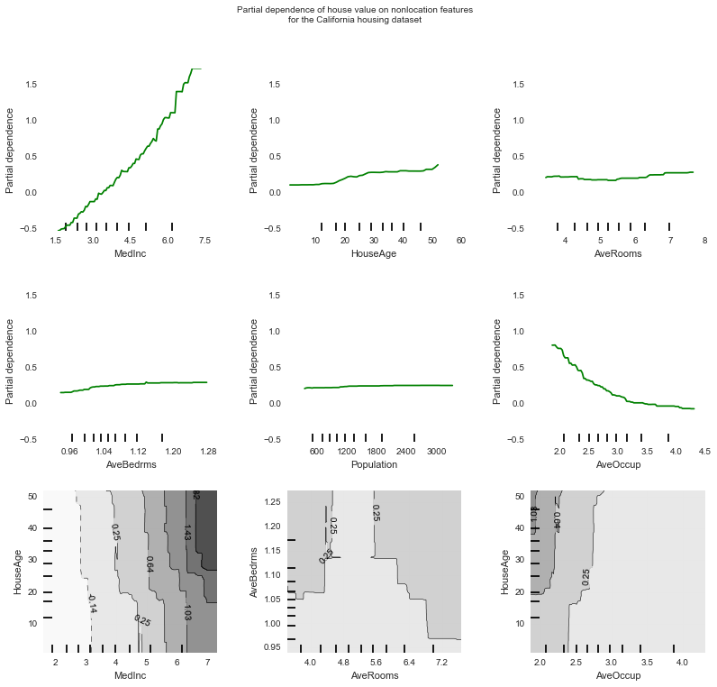

```python
# sklearn uses Matplotlib for its plotting functions (like `plot_partial_dependence')
%matplotlib inline
import matplotlib.pyplot as plt

features = [0, 1, 2, 3, 4, 5, (0,1), (2,3), (5, 1)]
fig = plt.figure(figsize=(12,12))
ax = fig.add_subplot(111)

fig, axs = plot_partial_dependence(clf, X_train, features, feature_names=names,
                                   n_jobs=-1, grid_resolution=100, ax=ax)
fig.suptitle('Partial dependence of house value on nonlocation features\n'
             'for the California housing dataset')
plt.subplots_adjust(top=0.9)  # tight_layout causes overlap with suptitle
```

Visit [www.add-for.com](http://www.add-for.com/IT) for more tutorials and updates.

This work is licensed under a [Creative Commons Attribution-ShareAlike 4.0 International License](http://creativecommons.org/licenses/by-sa/4.0/).